# 15_even_or_odd_graph

## 15_even_or_odd_graph

#### Question

1. This question is in regards to [even and odd functions](https://en.wikipedia.org/wiki/Even_and_odd_functions).
   - A function $f$ is **even** if and only if $f(-x)=f(x)$ for all $x$. In an even function, *opposite inputs give equal outputs*. An even function has reflective symmetry over the vertical axis.
   - A function $f$ is **odd** if and only if $f(-x)=-f(x)$ for all $x$. In an odd function, *opposite inputs give opposite outputs*. An odd function has rotational symmetry around the origin.
   - A function can also be neither even nor odd.

   A function $f$ is graphed below.

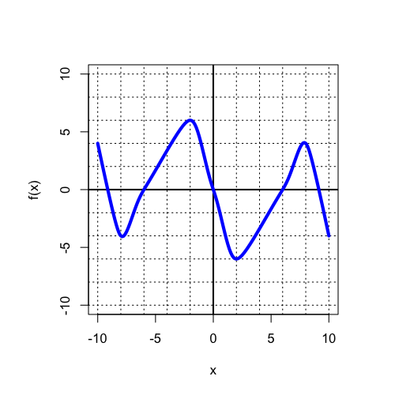

   Is the function’s graph consistent with the function being even, odd, or neither?
   1. Even
   2. Odd
   3. Neither

#### Solution

#### Question

2. This question is in regards to [even and odd functions](https://en.wikipedia.org/wiki/Even_and_odd_functions).
   - A function $f$ is **even** if and only if $f(-x)=f(x)$ for all $x$. In an even function, *opposite inputs give equal outputs*. An even function has reflective symmetry over the vertical axis.
   - A function $f$ is **odd** if and only if $f(-x)=-f(x)$ for all $x$. In an odd function, *opposite inputs give opposite outputs*. An odd function has rotational symmetry around the origin.
   - A function can also be neither even nor odd.

   A function $f$ is graphed below.

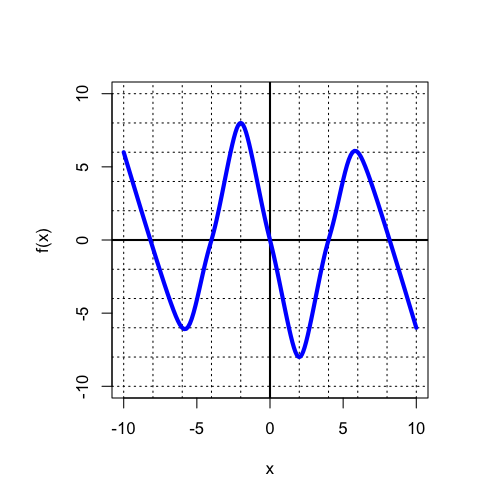

   Is the function’s graph consistent with the function being even, odd, or neither?
   1. Even
   2. Odd
   3. Neither

#### Solution

#### Question

3. This question is in regards to [even and odd functions](https://en.wikipedia.org/wiki/Even_and_odd_functions).
   - A function $f$ is **even** if and only if $f(-x)=f(x)$ for all $x$. In an even function, *opposite inputs give equal outputs*. An even function has reflective symmetry over the vertical axis.
   - A function $f$ is **odd** if and only if $f(-x)=-f(x)$ for all $x$. In an odd function, *opposite inputs give opposite outputs*. An odd function has rotational symmetry around the origin.
   - A function can also be neither even nor odd.

   A function $f$ is graphed below.

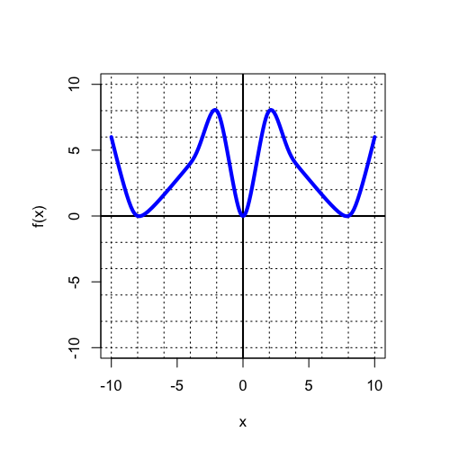

   Is the function’s graph consistent with the function being even, odd, or neither?
   1. Even
   2. Odd
   3. Neither

#### Solution

#### Question

4. This question is in regards to [even and odd functions](https://en.wikipedia.org/wiki/Even_and_odd_functions).
   - A function $f$ is **even** if and only if $f(-x)=f(x)$ for all $x$. In an even function, *opposite inputs give equal outputs*. An even function has reflective symmetry over the vertical axis.
   - A function $f$ is **odd** if and only if $f(-x)=-f(x)$ for all $x$. In an odd function, *opposite inputs give opposite outputs*. An odd function has rotational symmetry around the origin.
   - A function can also be neither even nor odd.

   A function $f$ is graphed below.

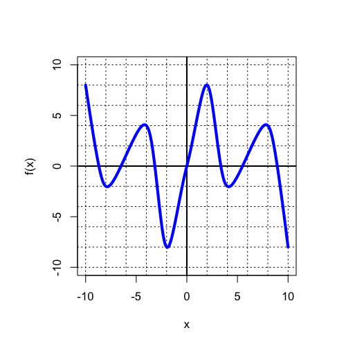

   Is the function’s graph consistent with the function being even, odd, or neither?
   1. Even
   2. Odd
   3. Neither

#### Solution

#### Question

5. This question is in regards to [even and odd functions](https://en.wikipedia.org/wiki/Even_and_odd_functions).
   - A function $f$ is **even** if and only if $f(-x)=f(x)$ for all $x$. In an even function, *opposite inputs give equal outputs*. An even function has reflective symmetry over the vertical axis.
   - A function $f$ is **odd** if and only if $f(-x)=-f(x)$ for all $x$. In an odd function, *opposite inputs give opposite outputs*. An odd function has rotational symmetry around the origin.
   - A function can also be neither even nor odd.

   A function $f$ is graphed below.

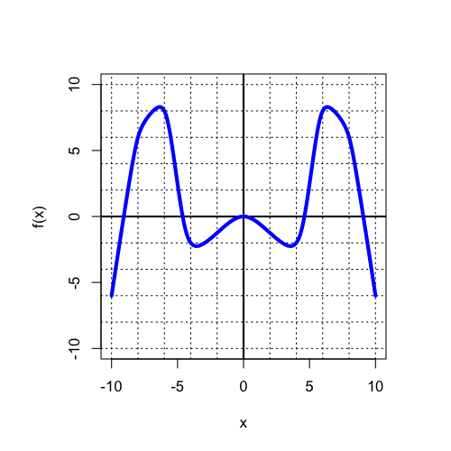

   Is the function’s graph consistent with the function being even, odd, or neither?
   1. Even
   2. Odd
   3. Neither

#### Solution

#### Question

6. This question is in regards to [even and odd functions](https://en.wikipedia.org/wiki/Even_and_odd_functions).
   - A function $f$ is **even** if and only if $f(-x)=f(x)$ for all $x$. In an even function, *opposite inputs give equal outputs*. An even function has reflective symmetry over the vertical axis.
   - A function $f$ is **odd** if and only if $f(-x)=-f(x)$ for all $x$. In an odd function, *opposite inputs give opposite outputs*. An odd function has rotational symmetry around the origin.
   - A function can also be neither even nor odd.

   A function $f$ is graphed below.

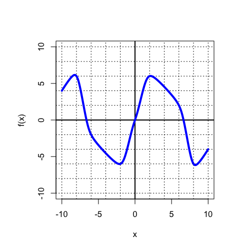

   Is the function’s graph consistent with the function being even, odd, or neither?
   1. Even
   2. Odd
   3. Neither

#### Solution

#### Question

7. This question is in regards to [even and odd functions](https://en.wikipedia.org/wiki/Even_and_odd_functions).
   - A function $f$ is **even** if and only if $f(-x)=f(x)$ for all $x$. In an even function, *opposite inputs give equal outputs*. An even function has reflective symmetry over the vertical axis.
   - A function $f$ is **odd** if and only if $f(-x)=-f(x)$ for all $x$. In an odd function, *opposite inputs give opposite outputs*. An odd function has rotational symmetry around the origin.
   - A function can also be neither even nor odd.

   A function $f$ is graphed below.

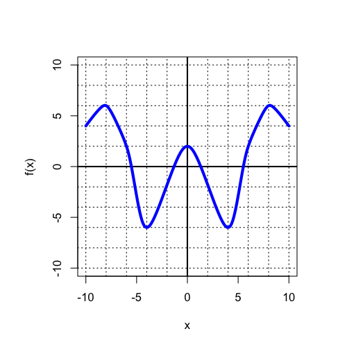

   Is the function’s graph consistent with the function being even, odd, or neither?
   1. Even
   2. Odd
   3. Neither

#### Solution

#### Question

8. This question is in regards to [even and odd functions](https://en.wikipedia.org/wiki/Even_and_odd_functions).
   - A function $f$ is **even** if and only if $f(-x)=f(x)$ for all $x$. In an even function, *opposite inputs give equal outputs*. An even function has reflective symmetry over the vertical axis.
   - A function $f$ is **odd** if and only if $f(-x)=-f(x)$ for all $x$. In an odd function, *opposite inputs give opposite outputs*. An odd function has rotational symmetry around the origin.
   - A function can also be neither even nor odd.

   A function $f$ is graphed below.

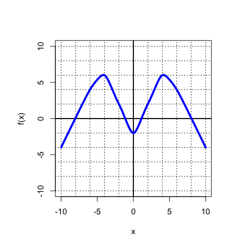

   Is the function’s graph consistent with the function being even, odd, or neither?
   1. Even
   2. Odd
   3. Neither

#### Solution